# The shape of kelp: environmental influences on kelp morphology

### The South African context

The biogeographic distribution of kelp is limited by seawater temperature (Bolton 2010), where increasing temperature gradients reduce kelp distribution. Due to this limiting factor, the two main species of kelps in southern African waters, *Ecklonia maxima* and *Laminaria pallida*, are distributed along a section of the south coast from De Hoop, extending west around the Cape Peninsula, and thriving north into Namibia (Molloy and Bolton 1996, Stegenga et al. 1997). This distribution follows a temperate gradient, where sea temperatures increase as one moves south from Namibia, around Cape Point and towards De Hoop. Although the two species occur together for the majority of the coast, their basic morphologies and resource needs vary to a degree. The larger species, *Ecklonia maxima*, is distributed from Lüderitz to Cape Agulhas (Fig. 1) (Bolton and Levitt 1985, Probyn and McQuaid 1985, Bolton and Anderson 1987, Bolton et al. 2012).

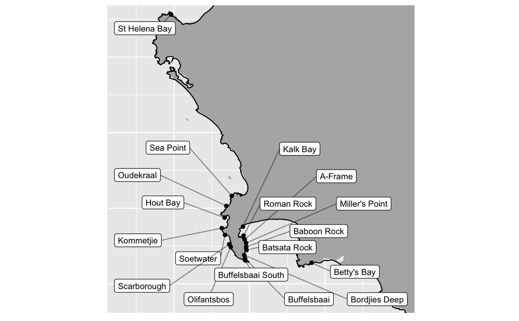

Characterised by a large distal swollen bulb filled with gas, and smooth fronds, this species grows to approximately 10 meters (Bolton and Anderson 1987). There was, however, a 17 m specimen collected in 2015 off Cape Point (Smit, unpubl. data). This species of kelp not only dominate the biomass of the South African nearshore, but plays an important ecological role (Bustamante and Branch 1996). The estimated productivity of *Ecklonia maxima* within South Africa varies between 350 and 1500 gC.m<sup>-2</sup>yr<sup>-1</sup> (Mann 1982). Across the majority of the coastline, *Laminaria pallida* remains a subsurface kelp, dominating the kelp biomass at depths greater than 10 m (Field et al. 1980a, Bolton and Anderson 1987, Molloy and Bolton 1996). This species is distributed from Danger Point, east of the Cape Peninsula, to Rocky Point in northern Namibia, and reaches depths of greater than 20 m (Field et al. 1980a, Molloy and Bolton 1996, Stegenga et al. 1997). Towards the north along the west coast, from around Hondeklipbaai, *Laminaria pallida* replaces *Ecklonia maxima* as the dominant kelp species (Velimirov et al. 1977, Stegenga et al. 1997) and it also occupies increasingly shallower subtidal regions. The northern populations also exhibit an increase in stipe hollowness, compared to the solid stipe morphs in the species’ southern distributions (Molloy and Bolton 1996). This variation in morphology was thought to represent two distinct species, with the northern populations formerly described as *Laminaria schinzii* Foslie (Molloy and Bolton 1996). Genetic work has subsequently shown that the two morphs are in fact the same species (Rothman et al. 2017). In southern African waters, the primary production of *Laminaria pallida* is between 120 and 1900g C m2yr1, similar to that of *Ecklonia maxima* (Mann 1982). Primary production is not the only pathway.

The aim of this study is, therefore, to understand how environmental drivers such as temperature and wave energy can influence morphoplasticity in two species of kelps around South Africa. This will be achieved by initially understanding the variation in abiotic parameters, and morphometrics of *Ecklonia maxima* and *Laminaria pallida*, around the Western Cape coast. Thereafter we will look at how the abiotic parameters both correlate and influence each other in the nearshore environment of our study region. Finally, we will investigate which abiotic parameters best describe the morphological variation of the two kelp species, using statistical tools. It is predicted that higher wave energy environments will exhibit kelps with reduced undulations, possessing strap-like blades, opposed to low flow regimes that will show greater undulations in frond morphology. An increase in temperature is predicted to influence specific morphological traits that rely on nutrient uptake, as temperature and nutrients share an inverse relationship. An increase in temperature is also predicted to reduce the dominance of the colder water kelp, *Laminaria pallida*, at depth, with a total absence of *Laminaria pallida* as one approaches the eastern boundary of sample sites.